# James Bond Tourism

James Bond must be the most well-travelled man in the history of movies. As it is summer time, let’s have a look at the 007 travel locations in the 24 films of the spy franchise with the R packages {maps}, {ggplot2} and {ggmap}.

In this article, we will answer three questions:

1. What are the countries that James Bond has visited?
2. Which countries has James Bond visited the most?
3. Have mission’s locations of James Bond changed over time?

## The Data

We can find on Wikipedia a full [list of James Bond film locations](https://en.wikipedia.org/wiki/List_of_James_Bond_film_locations). I copied the list on LibreOffice Calc and made some quick cleaning. For reproducibility, the data can be downloaded on my [Github repository](https://github.com/lgnbhl/lgnbhl.github.io/blob/masterimg/data_bond.csv).

```r
library(tidyverse)

bond <- read_csv("https://raw.githubusercontent.com/lgnbhl/lgnbhl.github.io/masterimg/data_bond.csv")

print(bond)
```

```
## # A tibble: 143 x 3
##                     Film                           Location         region
##                    <chr>                              <chr>          <chr>
##  1                Dr. No MI6 headquarters in central London        England
##  2                Dr. No                           Kingston        Jamaica
##  3                Dr. No                           Crab Key        Jamaica
##  4 From Russia with Love                      Unnamed river United Kingdom
##  5 From Russia with Love                             Zagreb        Croatia
##  6 From Russia with Love                           Belgrade         Serbia
##  7 From Russia with Love                           Istanbul         Turkey
##  8 From Russia with Love                             Venice          Italy
##  9            Goldfinger                         Stoke Park        England
## 10            Goldfinger                             Geneva    Switzerland
## # ... with 133 more rows
```

## Mapping Bond’s worldwide missions

We can count and map all the countries visited by James Bond in the film series. The package {ggalt} gives the possibility to choose between different map projections. We selected the [Winkel Tripel projection](https://en.wikipedia.org/wiki/Winkel_tripel_projection) for mapping.

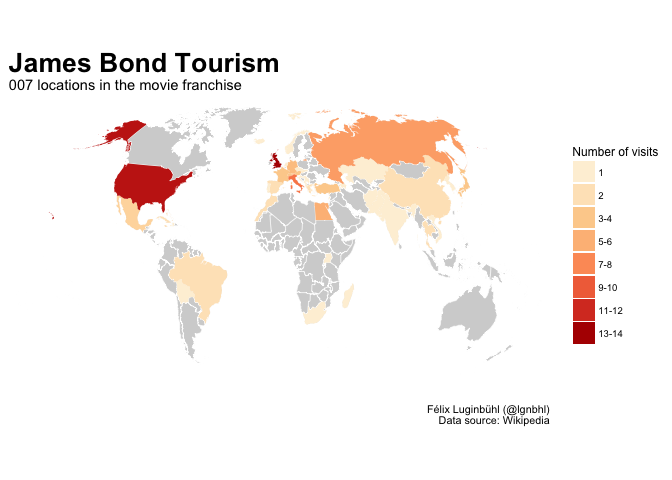

```r
library(maps)

world <- map_data("world") %>%
  filter(region != "Antarctica")

# Renaming regions for mapping
bond <- bond %>%
  mutate(region = recode(region,
    "United Kingdom" = "UK",
    "England" = "UK",
    "United States" = "USA"
  ))

bond_number <- bond %>%
  count(region, sort = TRUE)

library(ggalt)
library(ggthemes)

ggplot() +
  geom_map(data = world, map = world,
           aes(x = long, y = lat, map_id = region),
           fill="lightgrey", col="white", size = 0.2) +
  geom_map(data = bond_number, map = world,
           aes(map_id = region, fill = n)) +
  scale_fill_distiller(breaks = c(1, 2, 4, 6, 8, 10, 12, 14),
                       labels = c( "1", "2", "3-4", "5-6", "7-8", "9-10", "11-12", "13-14"),
                       name = "Number of visits",
                       palette = "OrRd", direction = 1,
                       guide = guide_legend(title.position = "top")) +
  ggalt::coord_proj("+proj=wintri") +
  ggthemes::theme_map() +
  theme(plot.title = element_text(size = 20, face = "bold"),
        plot.subtitle = element_text(size = 11),
        legend.position = "right",
        legend.justification = "center") +
  labs(title = "James Bond Tourism",
       subtitle = "007 locations in the movie franchise",
       caption = "Félix Luginbühl (@lgnbhl)\n Data source: Wikipedia")
```

James Bond has been to the United States 13 times. But in which movies did these visits happen?

```r
bond %>%
  select(Film, region) %>%
  filter(region == "USA") %>%
  count(Film, sort = TRUE) %>%
  rename(US_visits_by_film = n)
```

```
## # A tibble: 9 x 2
##                   Film US_visits_by_film
##                  <chr>             <int>
## 1           Goldfinger                 3
## 2 Diamonds Are Forever                 2
## 3     Live and Let Die                 2
## 4     A View to a Kill                 1
## 5        Casino Royale                 1
## 6      Licence to Kill                 1
## 7            Moonraker                 1
## 8          Thunderball                 1
## 9  You Only Live Twice                 1
```